# Phase 1

### Indroduction

I am interested in studying data on employment and productivity, because I am interested to see what kind of correlations there could be between things such as hours worked, compensation, profits, and productivity. I think it will be useful to about any relationships between these factors, so that we can figure out the best way to have people work.

### Dataset

Before we start we will need to load a library called “tidyverse”, since we will be using it later on.

```r
suppressMessages(library("tidyverse"))
```

Now lets load in the data from “https://www.bls.gov/lpc/major_sector_lpc_data.csv”.

```r
data <- read.csv("https://www.bls.gov/lpc/major_sector_lpc_data.csv")
```

Now let’s take a look at our data to see what data there is.

```r
head(data)
```

|  | Major.Sectors | Year | Quarter | Employment..percent.change.from.same.quarter.a.year.ago. | Employment..percent.change.from.previous.quarter.at.annual.rate. | Employment..2012...100. | Average.weekly.hours.worked..percent.change.from.same.quarter.a.year.ago. | Average.weekly.hours.worked..percent.change.from.previous.quarter.at.annual.rate. | Average.weekly.hours.worked..2012...100. | Hours.worked..percent.change.from.same.quarter.a.year.ago. | Hours.worked..percent.change.from.previous.quarter.at.annual.rate. | Hours.worked..2012...100. | Output..percent.change.from.same.quarter.a.year.ago. | Output..percent.change.from.previous.quarter.at.annual.rate. | Output..2012...100. | Current.dollar.output..percent.change.from.same.quarter.a.year.ago. | Current.dollar.output..percent.change.from.previous.quarter.at.annual.rate. | Current.dollar.output..2012...100. | Compensation..percent.change.from.same.quarter.a.year.ago. | Compensation..percent.change.from.previous.quarter.at.annual.rate. | Compensation..2012...100. | Nonlabor.payments..percent.change.from.same.quarter.a.year.ago. | Nonlabor.payments..percent.change.from.previous.quarter.at.annual.rate. | Nonlabor.payments..2012...100. | Labor.productivity..percent.change.from.same.quarter.a.year.ago. | Labor.productivity..percent.change.from.previous.quarter.at.annual.rate. | Labor.productivity..2012...100. | Hourly.compensation..percent.change.from.same.quarter.a.year.ago. | Hourly.compensation..percent.change.from.previous.quarter.at.annual.rate. | … |
| --- | --- | --- | --- | --- | --- | --- | --- | --- | --- | --- | --- | --- | --- | --- | --- | --- | --- | --- | --- | --- | --- | --- | --- | --- | --- | --- | --- | --- | --- | --- |
| 1 | Business | 1947 | Q01 | NA | NA | 46.909 | NA | NA | 116.208 | NA | NA | 54.512 | NA | NA | 11.096 | NA | NA | 1.625 | NA | NA | 1.889 | NA | NA | 1.286 | NA | NA | 20.355 | NA | NA | … |
| 2 | Business | 1947 | Q02 | NA | -1.4 | 46.739 | NA | 0.9 | 116.480 | NA | -0.5 | 54.441 | NA | 1.2 | 11.130 | NA | 6.8 | 1.652 | NA | 11.5 | 1.941 | NA | -1.2 | 1.282 | NA | 1.8 | 20.444 | NA | 12.2 | … |
| 3 | Business | 1947 | Q03 | NA | 4.6 | 47.268 | NA | -1.4 | 116.068 | NA | 3.1 | 54.863 | NA | -0.9 | 11.104 | NA | 10.0 | 1.692 | NA | 9.6 | 1.986 | NA | 10.7 | 1.315 | NA | -3.9 | 20.240 | NA | 6.1 | … |
| 4 | Business | 1947 | Q04 | NA | 3.6 | 47.693 | NA | -0.6 | 115.905 | NA | 3.1 | 55.279 | NA | 8.6 | 11.336 | NA | 21.1 | 1.775 | NA | 18.9 | 2.074 | NA | 25.6 | 1.392 | NA | 5.4 | 20.507 | NA | 15.5 | … |
| 5 | Business | 1947 | Q05 | NA | NA | 47.152 | NA | NA | 116.119 | NA | NA | 54.752 | NA | NA | 11.166 | NA | NA | 1.686 | NA | NA | 1.972 | NA | NA | 1.319 | NA | NA | 20.394 | NA | NA | … |
| 6 | Business | 1948 | Q01 | 1.4 | -1.0 | 47.571 | -0.5 | -1.0 | 115.604 | 0.9 | -2.0 | 54.994 | 4 | 7.4 | 11.541 | 12.1 | 10.8 | 1.821 | 10.7 | 3.5 | 2.092 | 14.5 | 25.4 | 1.473 | 3.1 | 9.7 | 20.986 | 9.8 | 5.5 | … |

```r
nrow(data)
```

```
## [1] 1252
```

```r
ncol(data)
```

```
## [1] 60
```

Now that we have an idea of what the data looks like, lets fix up the column names a little so that it is easier to read. We will change all the spots where it says “2012…100” to “2012.100” and we will also change all the spots where there’s two periods to only have one.

```r
names(data) <- gsub(x = names(data), pattern = "\\.\\.\\.", replacement = "\\.")
names(data) <- gsub(x = names(data), pattern = "\\.\\.", replacement = "\\.")
```

### Source

This dataset comes from the U.S. Bureau of Labor Statistics which is a very reliable source since they are part of the U.S. government. They have documented how and where they got the data from, so you can know that it is reliable.

### Variables

Now we will take a look at all the variables in the dataset. We will first print them all out, then look at each one individually.

```r
colnames(data)
```

```
##  [1] "Major.Sectors"
##  [2] "Year"
##  [3] "Quarter"
##  [4] "Employment.percent.change.from.same.quarter.a.year.ago."
##  [5] "Employment.percent.change.from.previous.quarter.at.annual.rate."
##  [6] "Employment.2012.100."
##  [7] "Average.weekly.hours.worked.percent.change.from.same.quarter.a.year.ago."
##  [8] "Average.weekly.hours.worked.percent.change.from.previous.quarter.at.annual.rate."
##  [9] "Average.weekly.hours.worked.2012.100."
## [10] "Hours.worked.percent.change.from.same.quarter.a.year.ago."
## [11] "Hours.worked.percent.change.from.previous.quarter.at.annual.rate."
## [12] "Hours.worked.2012.100."
## [13] "Output.percent.change.from.same.quarter.a.year.ago."
## [14] "Output.percent.change.from.previous.quarter.at.annual.rate."
## [15] "Output.2012.100."
```

[output cut: 45 more lines]

####The actual variables are: **Employment:** The total numbers of wage and salary workers, unincorporated self-employed workers, and unpaid family workers working within business establishments. An individual who works multiple jobs at separate establishments would have each job included in the number of employees.  
**Average.weekly.hours.worked:** The total number of hours worked over a specified period of time, divided by the total number of weeks worked in the time period.  
**Hours.worked:** The total number of hours worked by wage and salary workers, unincorporated self-employed workers, and unpaid family workers to produce output.  
**Output:** The amount of goods and services produced.  
**Current.dollar.output:** The value of goods and services produced, expressed in current dollars.  
**Compensation:** Monetary and non-monetary payments to or on behalf of individuals for labor services used to produce output. Compensation may include salaries, wages, bonuses, contributions to benefits plans, and other forms of payment.  
**Nonlabor.payments:** The value of output less the cost for labor services.  
**Labor.productivity:** The efficiency at which labor hours are utilized in producing output of goods and services, measured as output per hour of labor.  
**Hourly.compensation:** The sum of wage and salary accruals and supplements to wages and salaries per hour of labor services used to produce output. Wage and salary accruals consist of the monetary remuneration of employees. Supplements to wages and salaries consist of employer contributions for social insurance and employer payments (including payments in kind) to private pension and profit-sharing plans, group health and life insurance plans, privately administered workers’ compensation plans.  
**Unit.labor.costs:** The compensation for labor services used to produce each unit of goods and services.  
**Unit.nonlabor.costs:** The costs (payments) for each unit of goods and services produced after excluding labor costs and profits from the cost (value) of output.  
**Unit.nonlabor.payments:** The costs (payments) for each unit of goods and services produced after excluding labor costs and profits from the cost (value) of output.  
**Implicit.price.deflator:** An index of the change over time in the value of output relative to a base period.  
**Real.hourly.compensation:** The average monetary payments made to individuals for an hour of labor service, adjusted for inflation.  
**Output.per.job:** Output per job represents the amount of goods or services a person engaged in a particular occupation (job) can produce over an interval of time, such as a year, regardless of the actual number of hours worked. Output per job can be thought of a measure of output per person that is adjusted for the notion that a person can hold multiple jobs at the same time.  
**Labor.share:** The portion of the total costs to produce output that can be attributed to the cost of labor.  
**Profits:** The portion of total income from the sale of goods and services that exceeds the total costs of producing those goods and services.  
**Unit.profits:** Corporate profits before taxes with inventory valuation and capital consumption adjustments. Total unit costs, less labor costs, are profits.  
**Total.unit.costs:** The total payments (costs) for each unit of output produced where costs are measured as a difference between total income and profits.

The first table will be called from_year_ago and contain all the variables that are measuring the percent change from the same quarter a year ago.

```r
from_year_ago <- tibble(major_sectors=data$Major.Sectors, year=data$Year, quarter=data$Quarter,
                        Employment=data$Employment.percent.change.from.same.quarter.a.year.ago.,
                        Average_weekly_hours_worked=data$Average.weekly.hours.worked.percent.change.from.same.quarter.a.year.ago.,
                        Hours_worked=data$Hours.worked.percent.change.from.same.quarter.a.year.ago.,
                        Output=data$Output.percent.change.from.same.quarter.a.year.ago.,
                        Current_dollar_output=data$Current.dollar.output.percent.change.from.same.quarter.a.year.ago.,
                        Compensation=data$Compensation.percent.change.from.same.quarter.a.year.ago.,
                        Nonlabor_payments=data$Nonlabor.payments.percent.change.from.same.quarter.a.year.ago.,
                        Labor_productivity=data$Labor.productivity.percent.change.from.same.quarter.a.year.ago.,
                        Hourly_compensation=data$Hourly.compensation.percent.change.from.same.quarter.a.year.ago.,
                        Unit_labor_costs=data$Unit.labor.costs.percent.change.from.same.quarter.a.year.ago.,
                        Unit_nonlabor_costs=data$Unit.nonlabor.costs.percent.change.from.same.quarter.a.year.ago.,
                        Unit_nonlabor_payments=data$Unit.nonlabor.payments.percent.change.from.same.quarter.a.year.ago.,
                        Implicit_price_deflator=data$Implicit.price.deflator.percent.change.from.same.quarter.a.year.ago.,
                        Real_hourly_compensation=data$Real.hourly.compensation.percent.change.from.same.quarter.a.year.ago.,
                        Output_per_job=data$Output.per.job.percent.change.from.same.quarter.a.year.ago.,
                        Labor_share=data$Labor.share.percent.change.from.same.quarter.a.year.ago.,
                        Profits=data$Profits.percent.change.from.same.quarter.a.year.ago.,
                        Unit_profits=data$Unit.profits.percent.change.from.same.quarter.a.year.ago.,
                        Total_unit_costs=data$Total.unit.costs.percent.change.from.same.quarter.a.year.ago.)
```

The second table will be called from_previous_quarter and contain all the variables that are measuring the percent change from the previous quarter at an annual rate.

```r
from_previous_quarter <- tibble(major_sectors=data$Major.Sectors, year=data$Year, quarter=data$Quarter,
                        Employment=data$Employment.percent.change.from.previous.quarter.at.annual.rate.,
                        Average_weekly_hours_worked=data$Average.weekly.hours.worked.percent.change.from.previous.quarter.at.annual.rate.,
                        Hours_worked=data$Hours.worked.percent.change.from.previous.quarter.at.annual.rate.,
                        Output=data$Output.percent.change.from.previous.quarter.at.annual.rate.,
                        Current_dollar_output=data$Current.dollar.output.percent.change.from.previous.quarter.at.annual.rate.,
                        Compensation=data$Compensation.percent.change.from.previous.quarter.at.annual.rate.,
                        Nonlabor_payments=data$Nonlabor.payments.percent.change.from.previous.quarter.at.annual.rate.,
                        Labor_productivity=data$Labor.productivity.percent.change.from.previous.quarter.at.annual.rate.,
                        Hourly_compensation=data$Hourly.compensation.percent.change.from.previous.quarter.at.annual.rate.,
                        Unit_labor_costs=data$Unit.labor.costs.percent.change.from.previous.quarter.at.annual.rate.,
                        Unit_nonlabor_costs=data$Unit.nonlabor.costs.percent.change.from.previous.quarter.at.annual.rate.,
                        Unit_nonlabor_payments=data$Unit.nonlabor.payments.percent.change.from.previous.quarter.at.annual.rate.,
                        Implicit_price_deflator=data$Implicit.price.deflator.percent.change.from.previous.quarter.at.annual.rate.,
                        Real_hourly_compensation=data$Real.hourly.compensation.percent.change.from.previous.quarter.at.annual.rate.,
                        Output_per_job=data$Output.per.job.percent.change.from.previous.quarter.at.annual.rate.,
                        Labor_share=data$Labor.share.percent.change.from.previous.quarter.at.annual.rate.,
                        Profits=data$Profits.percent.change.from.previous.quarter.at.annual.rate.,
                        Unit_profits=data$Unit.profits.percent.change.from.previous.quarter.at.annual.rate.,
                        Total_unit_costs=data$Total.unit.costs.percent.change.from.previous.quarter.at.annual.rate.)
```

The third table will be called where_2012_is_100 and contain all the variables that are scaled so that at the year 2012 the value will be 100.

```r
where_2012_is_100 <- tibble(major_sectors=data$Major.Sectors, year=data$Year, quarter=data$Quarter,
                        Employment=data$Employment.2012.100.,
                        Average_weekly_hours_worked=data$Average.weekly.hours.worked.2012.100.,
                        Hours_worked=data$Hours.worked.2012.100.,
                        Output=data$Output.2012.100.,
                        Current_dollar_output=data$Current.dollar.output.2012.100.,
                        Compensation=data$Compensation.2012.100.,
                        Nonlabor_payments=data$Nonlabor.payments.2012.100.,
                        Labor_productivity=data$Labor.productivity.2012.100.,
                        Hourly_compensation=data$Hourly.compensation.2012.100.,
                        Unit_labor_costs=data$Unit.labor.costs.2012.100.,
                        Unit_nonlabor_costs=data$Unit.nonlabor.costs.2012.100.,
                        Unit_nonlabor_payments=data$Unit.nonlabor.payments.2012.100.,
                        Implicit_price_deflator=data$Implicit.price.deflator.2012.100.,
                        Real_hourly_compensation=data$Real.hourly.compensation.2012.100.,
                        Output_per_job=data$Output.per.job.2012.100.,
                        Labor_share=data$Labor.share.2012.100.,
                        Profits=data$Profits.2012.100.,
                        Unit_profits=data$Unit.profits.2012.100.,
                        Total_unit_costs=data$Total.unit.costs.2012.100.)
```

First lets look at the table measuring the percent change from the same quarter a year ago.

```r
summary(from_year_ago)
```

```
##                    major_sectors      year      quarter     Employment
##  Business                 :363   Min.   :1947   Q01:252   Min.   :-12.300
##  Manufacturing            :163   1st Qu.:1967   Q02:252   1st Qu.: -0.100
##  Nonfarm Business         :363   Median :1988   Q03:252   Median :  1.700
##  Nonfinancial Corporations:363   Mean   :1985   Q04:248   Mean   :  1.193
##                                  3rd Qu.:2003   Q05:248   3rd Qu.:  2.700
##                                  Max.   :2019             Max.   : 10.700
##                                                           NA's   :20
##  Average_weekly_hours_worked  Hours_worked         Output
##  Min.   :-3.1000             Min.   :-15.000   Min.   :-15.600
##  1st Qu.:-0.7000             1st Qu.: -0.500   1st Qu.:  1.600
##  Median :-0.2000             Median :  1.600   Median :  3.400
##  Mean   :-0.1786             Mean   :  1.017   Mean   :  3.308
##  3rd Qu.: 0.3000             3rd Qu.:  2.825   3rd Qu.:  5.300
##  Max.   : 3.6000             Max.   : 12.400   Max.   : 21.400
##  NA's   :20                  NA's   :20        NA's   :20
##  Current_dollar_output  Compensation     Nonlabor_payments Labor_productivity
##  Min.   :-17.200       Min.   :-11.100   Min.   :-19.600   Min.   :-4.400
##  1st Qu.:  4.150       1st Qu.:  3.700   1st Qu.:  3.100   1st Qu.: 0.900
##  Median :  6.200       Median :  5.700   Median :  6.400   Median : 2.200
##  Mean   :  6.355       Mean   :  5.749   Mean   :  6.711   Mean   : 2.275
##  3rd Qu.:  8.600       3rd Qu.:  8.100   3rd Qu.: 10.000   3rd Qu.: 3.500
##  Max.   : 27.700       Max.   : 23.300   Max.   : 35.500   Max.   : 9.500
##  NA's   :149           NA's   :20        NA's   :149       NA's   :20
##  Hourly_compensation Unit_labor_costs Unit_nonlabor_costs
##  Min.   :-0.700      Min.   :-6.600   Min.   :-9.100
##  1st Qu.: 3.000      1st Qu.: 0.500   1st Qu.: 0.000
##  Median : 4.200      Median : 2.100   Median : 2.450
##  Mean   : 4.678      Mean   : 2.388   Mean   : 3.400
##  3rd Qu.: 6.200      3rd Qu.: 3.600   3rd Qu.: 6.075
##  Max.   :12.700      Max.   :13.200   Max.   :20.600
##  NA's   :20          NA's   :20       NA's   :894
##  Unit_nonlabor_payments Implicit_price_deflator Real_hourly_compensation
##  Min.   :-9.000         Min.   :-6.300          Min.   :-3.70
##  1st Qu.: 0.800         1st Qu.: 1.200          1st Qu.: 0.10
##  Median : 2.600         Median : 2.000          Median : 1.40
##  Mean   : 3.088         Mean   : 2.772          Mean   : 1.41
##  3rd Qu.: 4.900         3rd Qu.: 3.600          3rd Qu.: 2.60
##  Max.   :19.100         Max.   :13.700          Max.   : 7.80
##  NA's   :149            NA's   :149             NA's   :20
##  Output_per_job    Labor_share         Profits         Unit_profits
##  Min.   :-6.900   Min.   :-9.0000   Min.   :-28.200   Min.   :-23.900
##  1st Qu.: 0.700   1st Qu.:-1.2000   1st Qu.: -4.775   1st Qu.: -6.650
##  Median : 1.900   Median :-0.1000   Median :  6.000   Median :  1.650
##  Mean   : 2.093   Mean   :-0.1723   Mean   :  6.955   Mean   :  2.808
##  3rd Qu.: 3.500   3rd Qu.: 1.0000   3rd Qu.: 16.775   3rd Qu.: 10.375
##  Max.   :11.800   Max.   :10.5000   Max.   : 65.500   Max.   : 57.500
##  NA's   :20       NA's   :149       NA's   :894       NA's   :894
##  Total_unit_costs
##  Min.   :-4.900
##  1st Qu.: 0.500
##  Median : 2.300
##  Mean   : 2.772
##  3rd Qu.: 4.300
##  Max.   :14.600
##  NA's   :894
```

Next, we’ll look at the table measuring the percent change from the previous quarter at an annual rate.

```r
summary(from_previous_quarter)
```

```
##                    major_sectors      year      quarter     Employment
##  Business                 :363   Min.   :1947   Q01:252   Min.   :-17.10
##  Manufacturing            :163   1st Qu.:1967   Q02:252   1st Qu.: -0.20
##  Nonfarm Business         :363   Median :1988   Q03:252   Median :  1.70
##  Nonfinancial Corporations:363   Mean   :1985   Q04:248   Mean   :  1.21
##                                  3rd Qu.:2003   Q05:248   3rd Qu.:  2.90
##                                  Max.   :2019             Max.   : 14.40
##                                                           NA's   :8
##  Average_weekly_hours_worked  Hours_worked         Output
##  Min.   :-5.5000             Min.   :-20.100   Min.   :-21.300
##  1st Qu.:-1.0000             1st Qu.: -0.700   1st Qu.:  0.900
##  Median :-0.2000             Median :  1.550   Median :  3.350
##  Mean   :-0.1776             Mean   :  1.042   Mean   :  3.372
##  3rd Qu.: 0.6000             3rd Qu.:  3.100   3rd Qu.:  5.800
##  Max.   : 6.7000             Max.   : 18.400   Max.   : 30.500
##  NA's   :8                   NA's   :8         NA's   :8
##  Current_dollar_output  Compensation     Nonlabor_payments Labor_productivity
##  Min.   :-19.400       Min.   :-25.500   Min.   :-34.300   Min.   :-11.700
##  1st Qu.:  3.575       1st Qu.:  2.800   1st Qu.:  1.675   1st Qu.:  0.400
##  Median :  6.100       Median :  5.700   Median :  6.400   Median :  2.100
##  Mean   :  6.438       Mean   :  5.815   Mean   :  7.020   Mean   :  2.312
##  3rd Qu.:  9.100       3rd Qu.:  9.100   3rd Qu.: 12.100   3rd Qu.:  4.025
##  Max.   : 35.100       Max.   : 28.200   Max.   : 50.800   Max.   : 19.600
##  NA's   :140           NA's   :8         NA's   :140       NA's   :8
##  Hourly_compensation Unit_labor_costs  Unit_nonlabor_costs
##  Min.   :-17.200     Min.   :-19.500   Min.   :-16.300
##  1st Qu.:  2.600     1st Qu.: -0.125   1st Qu.: -0.600
##  Median :  4.400     Median :  2.000   Median :  2.700
##  Mean   :  4.723     Mean   :  2.457   Mean   :  3.522
##  3rd Qu.:  7.000     3rd Qu.:  4.800   3rd Qu.:  6.800
##  Max.   : 16.400     Max.   : 27.300   Max.   : 32.900
##  NA's   :8           NA's   :8         NA's   :891
##  Unit_nonlabor_payments Implicit_price_deflator Real_hourly_compensation
##  Min.   :-23.000        Min.   :-6.600          Min.   :-18.900
##  1st Qu.: -0.300        1st Qu.: 1.100          1st Qu.: -0.400
##  Median :  2.600        Median : 2.100          Median :  1.200
##  Mean   :  3.234        Mean   : 2.799          Mean   :  1.449
##  3rd Qu.:  6.500        3rd Qu.: 3.900          3rd Qu.:  3.100
##  Max.   : 30.800        Max.   :19.400          Max.   : 20.600
##  NA's   :140            NA's   :140             NA's   :8
##  Output_per_job     Labor_share          Profits         Unit_profits
##  Min.   :-13.300   Min.   :-14.0000   Min.   :-60.800   Min.   :-54.000
##  1st Qu.:  0.000   1st Qu.: -2.0000   1st Qu.: -8.800   1st Qu.: -9.500
##  Median :  2.000   Median : -0.1000   Median :  5.900   Median :  1.700
##  Mean   :  2.132   Mean   : -0.1363   Mean   :  9.343   Mean   :  4.521
##  3rd Qu.:  4.100   3rd Qu.:  1.5000   3rd Qu.: 22.600   3rd Qu.: 15.900
##  Max.   : 21.300   Max.   : 13.9000   Max.   :166.500   Max.   :157.400
##  NA's   :8         NA's   :140        NA's   :891       NA's   :891
##  Total_unit_costs
##  Min.   :-8.900
##  1st Qu.:-0.100
##  Median : 2.300
##  Mean   : 2.831
##  3rd Qu.: 5.000
##  Max.   :26.200
##  NA's   :891
```

Finally, we’ll look at the table where the values are scaled so that at the year 2012 the value will be 100.

```r
summary(where_2012_is_100)
```

```
##                    major_sectors      year      quarter     Employment
##  Business                 :363   Min.   :1947   Q01:252   Min.   : 31.96
##  Manufacturing            :163   1st Qu.:1967   Q02:252   1st Qu.: 53.51
##  Nonfarm Business         :363   Median :1988   Q03:252   Median : 83.98
##  Nonfinancial Corporations:363   Mean   :1985   Q04:248   Mean   : 80.72
##                                  3rd Qu.:2003   Q05:248   3rd Qu.:101.77
##                                  Max.   :2019             Max.   :150.54
##
##  Average_weekly_hours_worked  Hours_worked        Output
##  Min.   : 95.65              Min.   : 36.21   Min.   :  8.589
##  1st Qu.:100.15              1st Qu.: 60.01   1st Qu.: 24.927
##  Median :103.20              Median : 86.09   Median : 52.669
##  Mean   :105.49              Mean   : 83.51   Mean   : 56.361
##  3rd Qu.:112.38              3rd Qu.:102.60   3rd Qu.: 91.551
##  Max.   :118.16              Max.   :149.00   Max.   :121.888
##
##  Current_dollar_output  Compensation     Nonlabor_payments Labor_productivity
##  Min.   :  1.434       Min.   :  1.644   Min.   :  1.153   Min.   : 20.24
##  1st Qu.:  4.875       1st Qu.:  6.301   1st Qu.:  4.371   1st Qu.: 41.51
##  Median : 25.733       Median : 38.353   Median : 22.918   Median : 57.36
##  Mean   : 39.186       Mean   : 47.147   Mean   : 36.234   Mean   : 61.64
##  3rd Qu.: 67.849       3rd Qu.: 87.317   3rd Qu.: 57.831   3rd Qu.: 85.75
##  Max.   :135.221       Max.   :136.787   Max.   :133.938   Max.   :107.93
##  NA's   :133                             NA's   :133
##  Hourly_compensation Unit_labor_costs Unit_nonlabor_costs
##  Min.   :  3.465     Min.   : 15.97   Min.   : 10.60
##  1st Qu.: 10.622     1st Qu.: 25.20   1st Qu.: 16.21
##  Median : 43.298     Median : 72.81   Median : 55.09
##  Mean   : 47.345     Mean   : 64.56   Mean   : 50.92
##  3rd Qu.: 78.627     3rd Qu.: 96.20   3rd Qu.: 77.07
##  Max.   :120.427     Max.   :116.31   Max.   :112.39
##                                       NA's   :889
##  Unit_nonlabor_payments Implicit_price_deflator Real_hourly_compensation
##  Min.   : 10.80         Min.   : 13.72          Min.   : 33.48
##  1st Qu.: 18.90         1st Qu.: 22.01          1st Qu.: 65.34
##  Median : 52.12         Median : 59.19          Median : 80.59
##  Mean   : 50.28         Mean   : 55.71          Mean   : 78.02
##  3rd Qu.: 70.74         3rd Qu.: 82.06          3rd Qu.: 97.26
##  Max.   :110.43         Max.   :111.18          Max.   :107.69
##  NA's   :133            NA's   :133
##  Output_per_job    Labor_share        Profits         Unit_profits
##  Min.   : 23.49   Min.   : 98.08   Min.   :  1.635   Min.   : 19.04
##  1st Qu.: 46.21   1st Qu.:107.83   1st Qu.:  5.615   1st Qu.: 26.21
##  Median : 59.39   Median :110.57   Median : 17.692   Median : 40.38
##  Mean   : 63.70   Mean   :109.92   Mean   : 32.358   Mean   : 47.82
##  3rd Qu.: 85.70   3rd Qu.:112.42   3rd Qu.: 48.919   3rd Qu.: 64.15
##  Max.   :107.14   Max.   :150.77   Max.   :118.107   Max.   :110.00
##                   NA's   :133      NA's   :889       NA's   :889
##  Total_unit_costs
##  Min.   : 16.30
##  1st Qu.: 21.75
##  Median : 62.30
##  Mean   : 57.25
##  3rd Qu.: 85.99
##  Max.   :114.89
##  NA's   :889
```

####Now lets look at some visualizations of the data.

[figure not shown]

```r
ggplot(from_previous_quarter, aes(x=year, y=Employment, group=major_sectors)) + geom_line(aes(color=major_sectors)) + labs(title="Percent Change in Employment from the Same Quarter a Year Ago", x="Year", y="Percent Change in Employment", color = "Major Sectors")
```

[figure not shown]

```r
ggplot(from_year_ago, aes(x=year, y=Hourly_compensation, group=major_sectors)) + geom_line(aes(color=major_sectors)) + labs(title="Percent Change in Hourly Compensation from the Previous Quarter at an Annual Rate", x="Year", y="Percent Change in Hourly Compensation", color = "Major Sectors")+ theme(plot.title = element_text(size=12))
```

Finally we will look at labor productivity where it’s scaled so that at the year 2012 the value will be 100, and have different lines based on the sector. An interesting thing that we can see from this is that manufacturing started out much lower that the other sectors, then increased quickly until around 2010 then slowed down and even started to decrease.

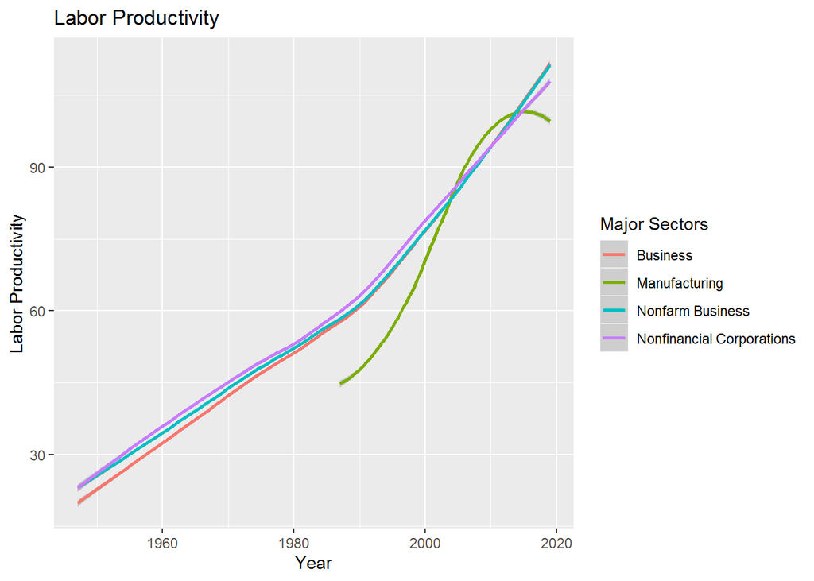

```r
ggplot(where_2012_is_100, aes(x=year, y=Labor_productivity, group=major_sectors)) + geom_smooth(aes(color=major_sectors)) + labs(title="Labor Productivity", x="Year", y="Labor Productivity", color = "Major Sectors")
```